# Data for: Do experimental pH increases alter the structure and function of a lowland tropical stream?

Nicholas S. Marzolf

Updated January 26, 2022

# Introduction

RMarkdown file to accompany “Do experimental pH increases alter the structure and function of a lowland tropical stream?”. This file contains the data files to recreate Tables 2-4 and Figures 2-6. The section for each figure loads in the appropriate data file to conduct the analysis and/or recreate the figure.

To recreate this HTML, load the data files into a folder named ‘Data’ at the same path as the .rmd file, open the .rmd file, and click ‘Knit’.

# Load packages

```r
library(readxl)    # read excel files
library(dplyr)     # data manipulation
library(tidyr)     # data manipulation
library(ggplot2)   # visualization
library(lubridate) # manage timestamps
library(cowplot)   # multipane figures
library(agricolae) # Tukey HSD test
library(ggsci)     # ggplot colors
library(moments)   # normality
library(emmeans)   # Estimated marginal means
library(car)       # Anova() function
library(effsize)   # Hedge's g effect size for low sample sizes
library(ARTool)    # Align rank transform test
library(vegan)     # Non-metric dimensional scaling
library(ggrepel)   # visualization
library(scales)    # plotting date-times
library(pander)    # session info

source('C:/Users/nmarz/Desktop/Research/R code/theme_nick.R')
theme_set(theme_nick())
```

# Table 2

Nutrients collected weekly in the 4 reaches during the 5 week experiment.

```r
nutrients <- read.csv('Data/nutrients.csv')     # nutrient data

nutrients %>%
  mutate(din = NOx_N + NH4_N,
         din_srp = (din/14.007)/(PO4_P/30.9737)
  ) %>%
  group_by(Reaches) %>%
  summarise(mean_NO3 = mean(NOx_N*1000),
            se_NO3 = sd(NOx_N*1000)/sqrt(length(NOx_N)),
            corNO3 = cor(y = NOx_N*1000, x = rep(1:6, 3), method = "kendall"),
            mean_NH4 = mean(NH4_N*1000),
            se_NH4 = sd(NH4_N*1000)/sqrt(length(NH4_N)),
            corNH4 = cor(y = NH4_N*1000, x = rep(1:6, 3), method = "kendall"),
            mean_PO4 = mean(PO4_P*1000),
            se_PO4 = sd(PO4_P*1000)/sqrt(length(PO4_P)),
            corPO4 = cor(y = PO4_P*1000, x = rep(1:6, 3), method = "kendall"),
            mean_NP = mean(din_srp),
            se_NP = sd(din_srp)/sqrt(length(din_srp)),
            corNP = cor(y = din_srp, x = rep(1:6, 3), method = "kendall"))
```

```
## # A tibble: 4 x 13
##   Reaches  mean_NO3 se_NO3 corNO3 mean_NH4 se_NH4   corNH4 mean_PO4 se_PO4
##   <chr>       <dbl>  <dbl>  <dbl>    <dbl>  <dbl>    <dbl>    <dbl>  <dbl>
## 1 Arb Down     198.   6.65  0.174     45.8   3.24 -0.174      36.8   4.12
## 2 Arb Up       243.   7.72  0.118     17.2   1.47 -0.00698     3.58  0.239
## 3 Car Down     158.   6.81 -0.216     32.0   9.36  0.0348      4.61  0.500
## 4 Car Up       150.   6.00 -0.223     25.7   3.47 -0.112       4.02  0.319
## # ... with 4 more variables: corPO4 <dbl>, mean_NP <dbl>, se_NP <dbl>,
## #   corNP <dbl>
```

# Table 3

Chironomid experiment data

```r
chiroGrowth <- read.csv('Data/chiroGrowth.csv') # Chironomid growth

chiroGrowth$Reach = factor(chiroGrowth$Reach)

chiroGrowth %>%
  group_by(Reach) %>%
  summarise(biomass_mean = mean(biomassFin_mg, na.rm = TRUE),
            biomass_se = sd(biomassFin_mg, na.rm = TRUE)/sqrt(length(biomassFin_mg)),
            per_biomass_mean = mean(delBiomass_per, na.rm = TRUE),
            per_biomass_se = sd(delBiomass_per, na.rm = TRUE)/sqrt(length(biomassFin_mg)),
            per_surv_mean = mean((numSurv/6)*100, na.rm = TRUE),
            per_surv_se = sd((numSurv/6)*100, na.rm = TRUE)/sqrt(length(biomassFin_mg)))
```

```
## # A tibble: 4 x 7
##   Reach    biomass_mean biomass_se per_biomass_mean per_biomass_se per_surv_mean
##   <fct>           <dbl>      <dbl>            <dbl>          <dbl>         <dbl>
## 1 ArbSeep~       0.0913    0.0186             155.            50.9          47.6
## 2 ArbSeep~       0.0296    0.00669             41.7           27.5          64.3
## 3 Carapa ~       0.0309    0.00610             65.4           34.2          72.9
## 4 Carapa ~       0.0318    0.00389             53.6           17.1          50
## # ... with 1 more variable: per_surv_se <dbl>
```

# Figure 2

Rainfall and pH time-series in the four reaches

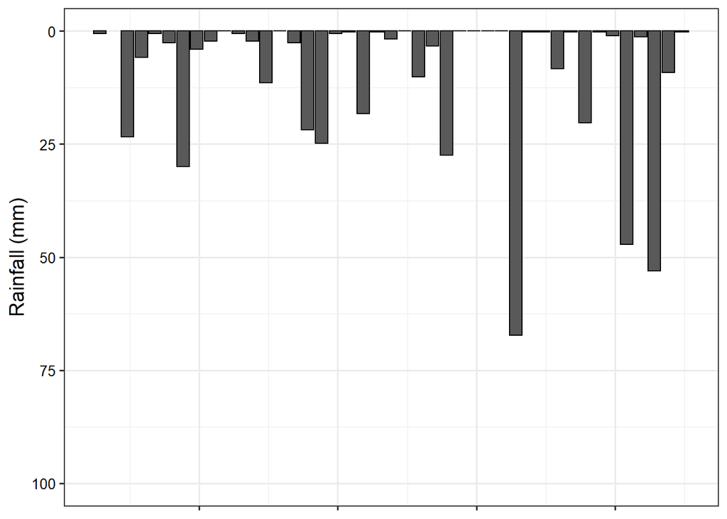

```r
# load the sensor data
CarDown <- read.csv('Data/CarDown.csv') # YSI EXO1 data- Carapa downstream
CarUp <- read.csv('Data/CarUp.csv')     # YSI EXO1 data- Carapa upstream
CarUp$Timestamp <- as.POSIXct(CarUp$Timestamp)
ArbDown <- read.csv('Data/ArbDown.csv') # YSI EXO1 data- ArbSeep downstream
ArbUp <- read.csv('Data/ArbUp.csv')     # YSI EXO1 data- ArbSeep upstream

# hyetographs for the 4 reaches
# the upstream rainfall is the same for both sites
CarUp_rain <- ggplot(CarUp %>%
                       group_by(Timestamp = as.POSIXct(date(Timestamp))) %>%
                       summarise(Rainfall = sum(Rainfall, na.rm = TRUE)),
                     aes(x = Timestamp,
                         y = Rainfall))+
  geom_bar(stat = 'identity', color = 'black')+
  ylim(100, 0)+
  scale_x_datetime(date_breaks = "10 day",
                   date_labels = "%m/%d/%y")+
  labs(y = 'Rainfall (mm)')+
  theme(axis.title.x = element_blank(),
        axis.text.x = element_blank(),
        axis.text.y = element_text(size = 10, face = 'plain'))
CarUp_rain
```

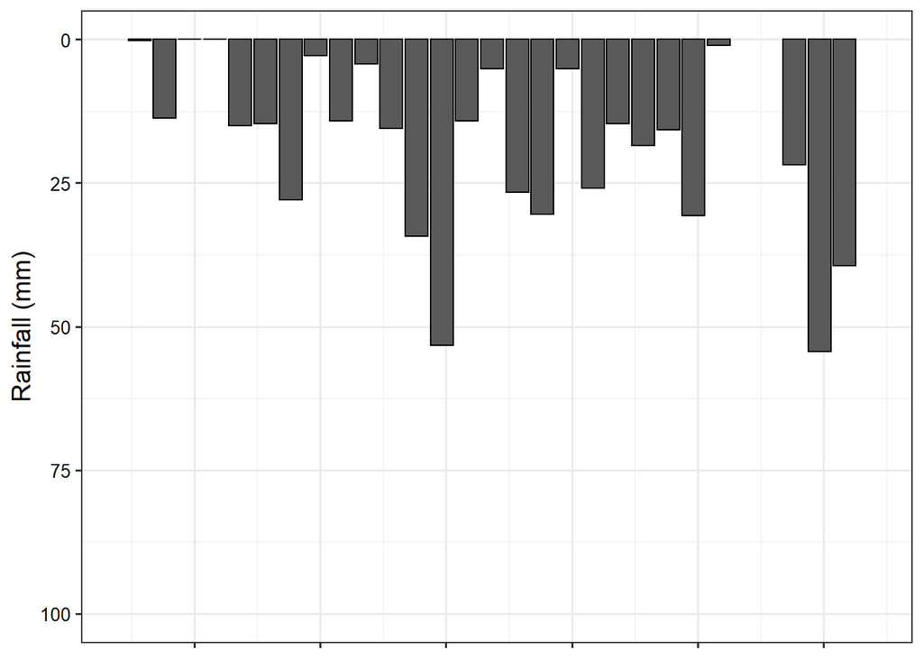

```r
ArbDown_rain <- ggplot(ArbDown %>%
                         group_by(Timestamp = date(Timestamp)) %>%
                         summarise(Rainfall = sum(Rainfall, na.rm = TRUE)),
                       aes(x = as.POSIXct(Timestamp),
                           y = Rainfall))+
  geom_bar(stat = 'identity',
           color = 'black')+
  ylim(100, 0)+
  ylab("Rainfall (mm)")+
  scale_x_datetime(date_breaks = "5 day",
                   date_labels = "%m/%d/%y",
                   limits = as.POSIXct(c("2018-06-18", "2018-07-18")))+
  theme(axis.title.x = element_blank(),
        axis.text.x = element_blank(),
        axis.text.y = element_text(size = 10))
ArbDown_rain
```

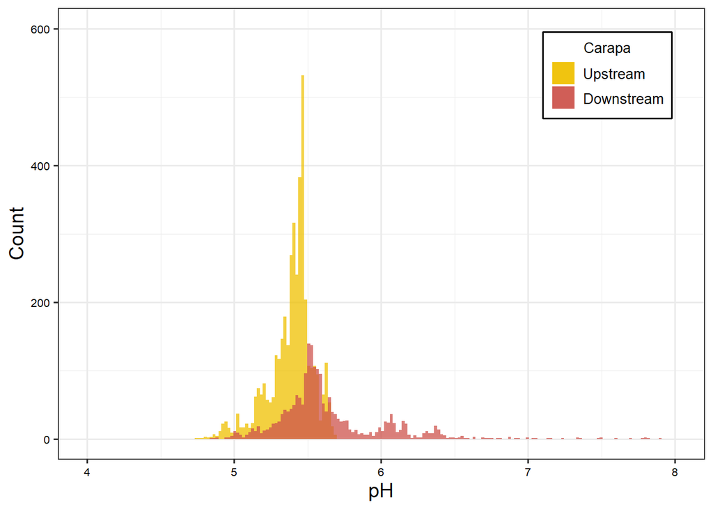

```r
# pH time-series in the 4 reaches
pH_downstream <- ggplot()+
  geom_point(data = ArbDown, alpha = 0.7,
             aes(x = as.POSIXct(Timestamp),
                 y = as.numeric(pH),
                 color = 'ArbSeep'))+
  geom_point(data = CarDown, alpha = 0.7,
             aes(x = as.POSIXct(Timestamp),
                 y  = as.numeric(pH),
                 color = 'Carapa'))+
  ylim(4, 8)+
  ylab('pH')+
  xlab('Date')+
  scale_x_datetime(date_breaks = "7 day",
                   date_labels = "%m/%d/%y",
                   limits = as.POSIXct(c("2018-06-18", "2018-07-18")))+
  scale_color_manual(name = 'Downstream Reach',
                     values = c('#868686FF', '#CD534CFF'))+
  theme(legend.position = c(0.22, 0.2),
        legend.background = element_rect(fill = "white", color = "black"),
        legend.text = element_text(size = 10),
        legend.title = element_text(size = 10),
        axis.text.x = element_text(size = 10))

pH_upstream <- ggplot()+
  geom_point(data = ArbUp, alpha = 0.7,
             aes(x = as.POSIXct(Timestamp),
                 y = pH,
                 color = 'ArbSeep'))+
  geom_point(data = CarUp, alpha = 0.7,
             aes(x = as.POSIXct(Timestamp),
                 y  = pH,
                 color = 'Carapa'))+
  ylim(4, 8)+
  xlab('Date')+
  scale_color_manual(name = 'Upstream Reach',
                     values = c('#0073C2FF', '#EFC000FF'))+
  scale_x_datetime(date_breaks = "10 day",
                   date_labels = "%m/%d/%y")+
  theme(legend.position = c(0.8, 0.8),
        legend.background = element_rect(fill = "white", color = "black"),
        legend.text = element_text(size = 10),
        legend.title = element_text(size = 10),
        axis.text.x = element_text(size = 10))

# paired histograms
Car_pairedHist <- ggplot()+
  geom_histogram(data = CarUp, bins = 200, alpha = 0.75,
                 aes(x = pH, fill = 'Upstream'))+
  geom_histogram(data = CarDown, bins = 200, alpha = 0.75,
                 aes(x = as.numeric(pH), fill = 'Downstream'))+
  xlim(4, 8)+
  ylim(0, 600)+
  ylab("Count")+
  scale_fill_manual(labels = c("Upstream", "Downstream"),
                    breaks = c("Upstream", "Downstream"),
                    values = c('#EFC000FF', '#CD534CFF'),
                    name = 'Carapa')+
  theme(legend.justification = c(0.75,0.75),
        legend.position = c(0.9,0.9),
        legend.text = element_text(face = 'plain', size = 10),
        legend.title = element_text(size = 10),
        legend.background = element_rect(color = 'black'),
        axis.text = element_text(size = 8))
Car_pairedHist
```

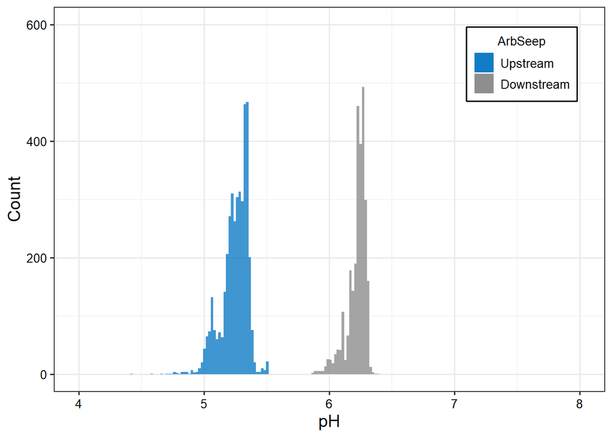

```r
Arb_pairedHist <- ggplot()+
  geom_histogram(data = ArbUp, bins = 200, alpha = 0.75,
                 aes(x = pH, fill = 'Upstream'))+
  geom_histogram(data = ArbDown, bins = 200, alpha = 0.75,
                 aes(x = as.numeric(pH), fill = 'Downstream'))+
  xlim(4, 8)+
  ylim(0, 600)+
  ylab("Count")+
  xlab("pH")+
  scale_fill_manual(labels = c("Upstream", "Downstream"),
                    breaks = c("Upstream", "Downstream"),
                    values = c('#0073C2FF', '#868686FF'),
                    name = 'ArbSeep')+
  theme(legend.justification = c(0.75,0.75),
        legend.position = c(0.9,0.9),
        legend.text = element_text(size = 10),
        legend.title = element_text(size = 10),
        legend.background = element_rect(color = 'black'),
        axis.text = element_text(size = 10))
Arb_pairedHist
```

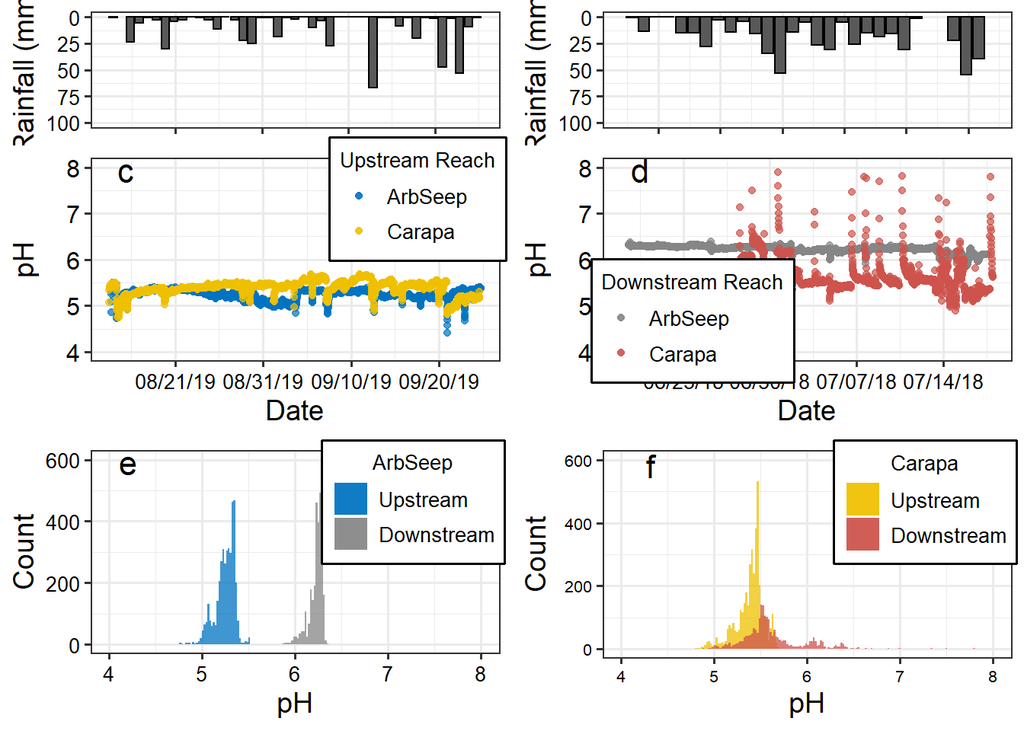

```r
# combine into Fig 2
fig2 <- plot_grid(CarUp_rain, ArbDown_rain,
                  pH_upstream, pH_downstream,
                  Arb_pairedHist, Car_pairedHist,
                  nrow = 3, ncol = 2,
                  rel_heights = c(0.5,1,1),
                  labels = 'auto', label_fontface = 'plain',
                  label_size = 16,
                  hjust = c(-6.5, -6.5,-7,-6.5,-6.5,-13.5),
                  vjust = c(7,7,1.5,1.5,1.5,1.6),
                  align = 'v')
fig2
```

# Figure 3

Leaf litter and coarse woody debris decomposition rates.

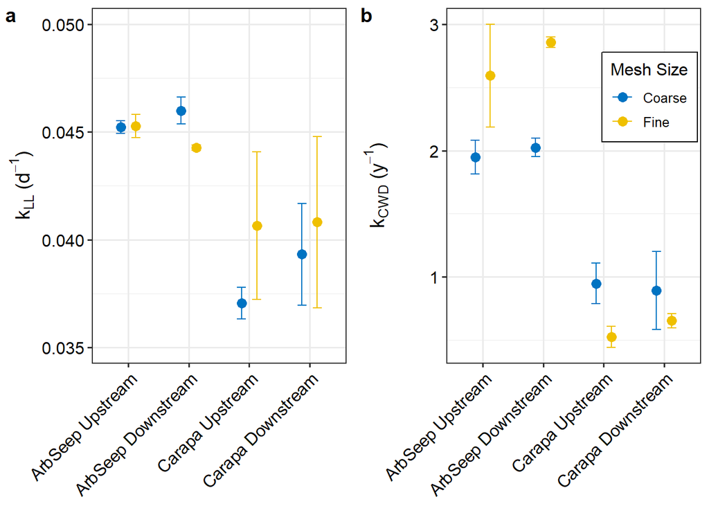

```r
OM <- read.csv('Data/OM.csv')                   # leaf litter and coarse woody debris decomposition rate data

OM$Reach = factor(OM$Reach,
                  levels = c('ArbSeep Upstream',
                             'ArbSeep Downstream',
                             'Carapa Upstream',
                             'Carapa Downstream'))

# leaf litter boxplot; letters are Tukey post-hoc test
plot_LL_k <- OM %>%
  select(Stream, Treatment, Reach, Bag_mesh, k_LL_d) %>%
  group_by(Reach, Bag_mesh) %>%
  summarise(mean_k = mean(k_LL_d, na.rm = TRUE),
            se_k = sd(k_LL_d, na.rm = TRUE)/length(k_LL_d)) %>%
  ggplot(., aes(x = Reach, y = mean_k,
                color = Bag_mesh))+
  geom_point(size = 3,
             position=position_dodge(width=0.5))+
  geom_errorbar(aes(ymin = mean_k - se_k,
                    ymax = mean_k + se_k),
                width = 0.3,
                position=position_dodge(width=0.5))+
  ylim(.035, 0.05)+
  scale_color_jco(name = 'Mesh Size')+
  ylab(expression(paste(k[LL], ' (',d^-1,')')))+
  theme(axis.title.x = element_blank(),
        axis.text.x = element_text(angle = 45, hjust = 1),
        legend.position = 'none')
# woody debris boxplot
plot_CWD_k <- OM %>%
  select(Stream, Treatment, Reach, Bag_mesh, k_CWD_yr) %>%
  group_by(Reach, Bag_mesh) %>%
  summarise(mean_k = mean(k_CWD_yr, na.rm = TRUE),
            se_k = sd(k_CWD_yr, na.rm = TRUE)/length(k_CWD_yr)) %>%
  ggplot(., aes(x = Reach, y = mean_k,
                color = Bag_mesh))+
  geom_point(size = 3,
             position=position_dodge(width=0.5))+
  geom_errorbar(aes(ymin = mean_k - se_k,
                    ymax = mean_k + se_k),
                width = 0.3,
                position=position_dodge(width=0.5))+
  #ylim(.035, 0.05)+
  scale_color_jco(name = 'Mesh Size')+
  ylab(expression(paste(k[CWD], ' (',y^-1,')')))+
  theme(axis.title.x = element_blank(),
        axis.text.x = element_text(angle = 45, hjust = 1),
        legend.position = c(0.8, 0.75),
        legend.background = element_blank(),
        legend.box.background = element_rect(colour = "black"))
# combine plots
plot_grid(plot_LL_k, plot_CWD_k,
          ncol = 2,
          labels = 'auto',
          align = 'hv')
```

# Figure 4

Macroinvertebrate abundance per g of organic matter AFDM

```r
macros <- read.csv('Data/macroinverts.csv')     # macroinvertebrate abundance for W1 and W5 data

# assign NAs to 0
macros[is.na(macros)] <- 0

# Family counts
glimpse(macros)
```

```
## Rows: 94
## Columns: 55
## $ X                 <int> 1, 2, 3, 4, 5, 6, 7, 8, 9, 10, 11, 12, 13, 14, 15, 1~
## $ Sample            <chr> "LeavesUB-Fine-1", "LeavesUB-Fine-2", "LeavesUB-Fine~
## $ Week              <chr> "W1", "W1", "W1", "W1", "W1", "W1", "W1", "W1", "W1"~
## $ Site              <chr> "Carapa", "Carapa", "Carapa", "Carapa", "Carapa", "C~
## $ Organic_Type      <chr> "Leaf", "Leaf", "Leaf", "Leaf", "Leaf", "Leaf", "Lea~
## $ Mesh_Size         <chr> "Fine", "Fine", "Fine", "Fine", "Fine", "Fine", "Coa~
## $ Reach             <chr> "Upstream", "Upstream", "Upstream", "Downstream", "D~
## $ Diptera           <int> 144, 62, 41, 56, 21, 17, 57, 92, 59, 49, 25, 34, 74,~
## $ Coleoptera        <int> 0, 0, 0, 0, 0, 0, 0, 1, 0, 0, 0, 1, 0, 0, 0, 0, 1, 0~
## $ Ephemeroptera     <int> 0, 0, 1, 0, 0, 0, 2, 10, 3, 3, 3, 2, 0, 2, 0, 0, 0, ~
## $ Trichoptera       <int> 0, 0, 0, 0, 0, 0, 1, 1, 0, 1, 0, 0, 0, 0, 0, 0, 0, 0~
## $ Plecoptera        <int> 0, 0, 0, 0, 0, 0, 0, 0, 0, 0, 0, 3, 0, 0, 0, 0, 0, 0~
## $ Odonata           <int> 0, 0, 0, 0, 0, 0, 0, 0, 0, 0, 0, 0, 0, 1, 0, 0, 1, 0~
```

[output cut: 42 more lines]

```r
# Make factors
macros$Week = factor(macros$Week)
macros$Organic_Type = factor(macros$Organic_Type)
macros$Mesh_Size = factor(macros$Mesh_Size)

# Subset data
macro_fam <- macros %>%
  mutate(Hydracarina = Hydracarina + Water.Mite) %>%
  select(-Water.Mite) %>%
  select(Sample:Reach, Chironomidae:Hydracarina) %>%
  mutate(Reaches = factor(interaction(Site, Reach, sep = ' '))) %>%
  rename(OM = Organic_Type,
         Mesh = Mesh_Size)

macro_fam$Reaches <- ordered(macro_fam$Reaches,
                             levels = c("Carapa Upstream", "Carapa Downstream",
                                        "ArbSeep Upstream", "ArbSeep Downstream"))


# convert data to mean abundance by family for LL litter bags
mean_fam_abun_LL = macro_fam %>%
  dplyr::rowwise(Sample) %>%
  dplyr::mutate(sum = rowSums(across(Chironomidae:Hydracarina))) %>%
  dplyr::group_by(Week, OM, Mesh, Reaches) %>%
  dplyr::summarise(mean = mean(sum),
                   se = sd(sum)/sqrt(length(sum)),
                   len = length(sum)) %>%
  dplyr::filter(OM == 'Leaf')
```

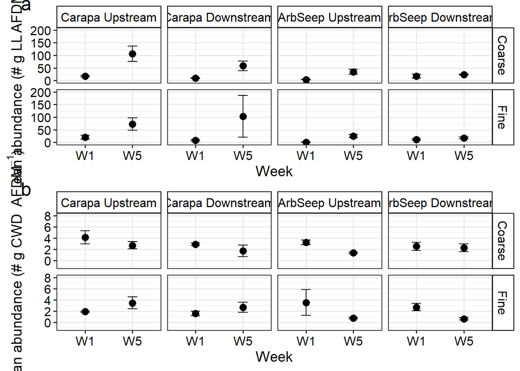

```r
# these data are the leaf litter AFDM remaining at Week 5 from the OM data file. Here, I load them in as a new column
mean_fam_abun_LL$LL_AFDM = c(4.4, 3.97, 4.28, 4.33, 4.07, 4.07, 4.4, 3.93,
                             0.59, 1.14, 0.91, 1.22, 0.63, 1.13, 0.91, 1.12)

# calculate the mean family abundance per g AFMD remaining
mean_fam_abun_LL = mean_fam_abun_LL %>%
  mutate(mean_abund_AFDM = mean/LL_AFDM,
         se_abund_AFDM = se/LL_AFDM)

# plot mean family abundance per g AFDM remaining
abundance_LL = ggplot(data = mean_fam_abun_LL,
                      aes(x = Week, y = mean_abund_AFDM))+
  geom_point(size = 3)+
  geom_errorbar(aes(ymin = mean_abund_AFDM - se_abund_AFDM,
                    ymax = mean_abund_AFDM + se_abund_AFDM),
                width = 0.2)+
  facet_grid(Mesh ~ Reaches)+
  scale_y_continuous(limit = c(0, 200),
                     breaks = c(0, 50, 100, 150, 200),
                     labels = c(0, 50, 100, 150, 200))+
  #scale_y_log10(limit = c(0.1, 300),
  #              breaks = c(0.1, 1, 10, 100, 300),
  #              labels = c(0.1, 1, 10, 100, 300))+
  ylab(expression(paste("Mean abundance (# g LL ", AFDM^-1,")")))+
  theme(strip.background = element_rect(color = "black", fill = "white"),
        strip.text = element_text(color = "black", size = 12))

# repeat the calculation for CWD litter bags
mean_fam_abun_CWD <- macro_fam %>%
  dplyr::rowwise(Sample) %>%
  mutate(sum = rowSums(across(Chironomidae:Hydracarina))) %>%
  group_by(Week, OM, Mesh, Reaches) %>%
  summarise(mean = mean(sum),
            se = sd(sum)/sqrt(length(sum))) %>%
  filter(OM == 'Wood')
# these are the CWD AFDM data, as described above
mean_fam_abun_CWD$CWD_AFDM <- c(36.8, 30.8, 38.3, 34.7, 40.2, 30.7, 40.9, 34.8,
                                35.6, 28.6, 25.8, 28.4, 23.7, 29.2, 24.4, 29.6)

# calculate mean family abundance per g AFDM
mean_fam_abun_CWD <- mean_fam_abun_CWD %>%
  mutate(mean_abund_AFDM = mean/CWD_AFDM,
         se_abund_AFDM = se/CWD_AFDM)

# create the plot
abundance_CWD <- ggplot(data = mean_fam_abun_CWD,
                        aes(x = Week, y = mean_abund_AFDM))+
  geom_point(size = 3)+
  geom_errorbar(aes(ymin = mean_abund_AFDM - se_abund_AFDM,
                    ymax = mean_abund_AFDM + se_abund_AFDM),
                width = 0.2)+
  facet_grid(Mesh ~ Reaches)+
  scale_y_continuous(limit = c(-1, 8),
                     breaks = c(0, 2, 4, 6, 8),
                     labels = c(0, 2, 4, 6, 8))+
  ylab(expression(paste("Mean abundance (# g CWD  ", AFDM^-1,")")))+
  theme(strip.background = element_rect(color = "black", fill = "white"),
        strip.text = element_text(color = "black", size = 12))

# combine OM abundance plots
Fig4 <- plot_grid(abundance_LL, abundance_CWD,
                  align = 'hv',
                  nrow = 2,
                  labels = 'auto', label_fontface = 'plain', label_size = 18,
                  hjust = -2, vjust = 0.75)
Fig4
```

# Figure 5

Species richness

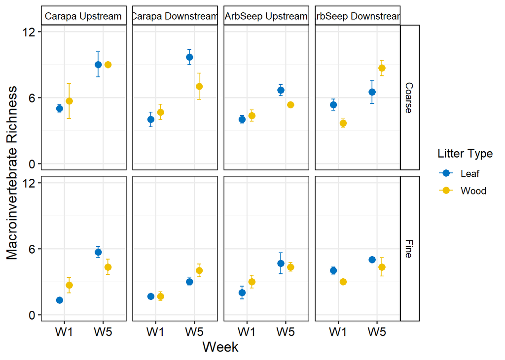

```r
macro_fam$numFam = specnumber(select(macro_fam, Chironomidae:Hydracarina))

Fig5 <- ggplot(macro_fam %>%
                 group_by(Week, OM, Reaches, Mesh) %>%
                 summarise(mean_rich = mean(numFam, na.rm = TRUE),
                           se_rich = sd(numFam, na.rm = TRUE)/length(numFam)),
               aes(x = Week,
                   y = mean_rich,
                   color = OM))+
  geom_point(size = 3,
             position=position_dodge(width=0.5))+
  geom_errorbar(aes(ymin = mean_rich - se_rich,
                    ymax = mean_rich + se_rich),
                width = 0.2,
                position=position_dodge(width=0.5))+
  facet_grid(Mesh~Reaches)+
  ylab("Macroinvertebrate Richness")+
  scale_y_continuous(limits = c(0, 12),
                     breaks = c(0, 6, 12),
                     labels = c(0, 6, 12))+
  scale_color_jco(name = 'Litter Type')+
  theme(strip.background = element_rect(color = "black", fill = "white"),
        strip.text = element_text(color = "black"))
Fig5
```

# Figure 6

Non-metric dimensional scaling of the various treatments in the experiment

```r
macro_fam_W5 <- macro_fam %>%
  filter(Week == 'W5') %>%
  mutate_at(vars(Chironomidae:Hydracarina),
            funs(log10(1+.)))

nmds <- metaMDS(macro_fam_W5 %>%
                  select(Chironomidae:Hydracarina),
                distance = 'bray',     # Bray-Curtis dissimilarity index
                k = 3,                 # specify 3 dimensions
                autotransform = FALSE) # we did this manually
```

```
## *** Solution reached
```

```r
nmds$stress # 0.17, not too bad
```

```
## [1] 0.1736873
```

Now let’s begin the visualization process. First, we will extract points from the ordination and bind them to the experimental treatment data not run in the NMDS matrix. We will then look at the taxa that are driving the dissimilarity in the matrix and plot the vectors on the NMDS points

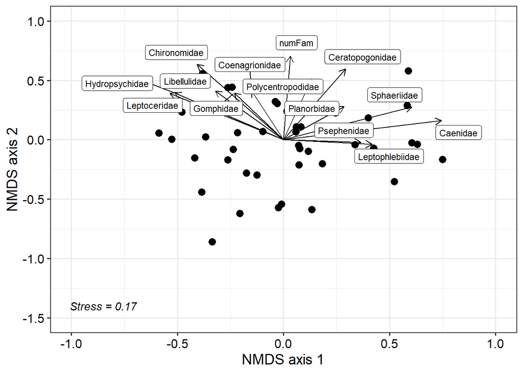

```r
df <- data.frame(x = nmds$points[,1],
                 y = nmds$points[,2],
                 z = nmds$points[,3])
df<-cbind(macro_fam_W5[,c(1:6, 40)],
          df)

fit<-(envfit(nmds, macro_fam_W5[,-c(1:6)],
             perm = 9999))
scrs <- as.data.frame(scores(fit, 'vectors'))
scrs$pvals = fit$vector$pvals
scrs_sig<-subset(scrs, pvals <= 0.05)
scrs_sig$env.variables = row.names(scrs_sig)

# plot nmds with significant family vectors
nmds_vect <- ggplot(data = df, aes(x = x, y = y))+
  geom_point(size = 3) +
  geom_segment(data = scrs_sig,
               aes(x = 0, xend = NMDS1,
                   y = 0, yend = NMDS2),
               arrow = arrow(length = unit(0.25, "cm")),
               colour = "black") +
  geom_label_repel(data = scrs_sig,
                   aes(NMDS1, NMDS2, label = env.variables),
                   size = 3)+
  labs(x = "NMDS axis 1", y = "NMDS axis 2")+
  annotate("text", label = "Stress = 0.17", x = -0.85, y = -1.4, fontface = 3)+
  lims(x = c(-1, 1), y = c(-1.5, 1))
nmds_vect
```

Now we will calculate 95% confidence interval ellipses for the four study reaches, two mesh bag sizes, and 2 organic matter types, and plot the ellipses on the NMDS to determine the similarity of the assemblage as explained by those treatments. We will need the veganCovEllipse.R function to help us. Briefly, we will create a dummy data frame that is run through a for loop that calculates the 95% CI ellipse for the treatment factor of interest. For the sake of space, I will show the process for the first 2 axes (x and y) but can repeated to visualize the NMDS using other axes (substitute y for x to change from axis 2 to 1, and substitute z for y to change from axis 2 to axis 3):

```r
source('veganCovEllipse.R')

ell_reaches_12 <- data.frame() # create a dummy data frame for ellipses based on reach for axes 1 and 2

for(g in unique(df$Reaches)) {
  ell_reaches_12 <- rbind(ell_reaches_12,
                          cbind(
                            as.data.frame(
                              with(df[df$Reaches == g,],
                                   veganCovEllipse(cov.wt(cbind(x, y),
                                                          wt = rep(1/length(x),
                                                                   length(x)))$cov,
                                                   center = c(mean(x),
                                                              mean(y)
                                                   )
                                   )
                              )
                            ),
                            Reaches = g)
  )
}

# repeat for OM and Mesh treatments
ell_OM_12 <- data.frame()

for(g in unique(df$OM)) {
  ell_OM_12 <- rbind(ell_OM_12,
                     cbind(
                       as.data.frame(
                         with(df[df$OM == g,],
                              veganCovEllipse(cov.wt(cbind(x, y),
                                                     wt = rep(1/length(x),
                                                              length(x)))$cov,
                                              center = c(mean(x),
                                                         mean(y)
                                              )
                              )
                         )
                       ),
                       OM = g)
  )
}

ell_mesh_12 <- data.frame()
for(g in unique(df$Mesh)) {
  ell_mesh_12 <- rbind(ell_mesh_12,
                       cbind(
                         as.data.frame(
                           with(df[df$Mesh == g,],
                                veganCovEllipse(cov.wt(cbind(x, y),
                                                       wt = rep(1/length(x),
                                                                length(x)))$cov,
                                                center = c(mean(x),
                                                           mean(y)
                                                )
                                )
                           )
                         ),
                         Mesh = g)
  )
}
```

Now we will plot the NMDS using the 95% CI ellipses we just calculated for reaches, organic matter, and mesh size. Then, we will combine the plots into Figure 6

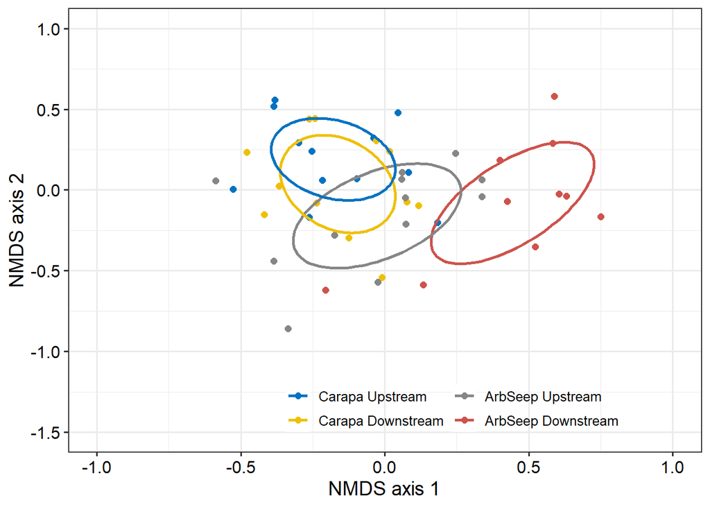

```r
# by reach
nmds_reaches <- ggplot(data = df,
                       aes(x = x, y = y))+
  geom_point(size = 2, aes(color = Reaches)) +
  geom_path(data = ell_reaches_12,
            aes(x = x, y = y, color = Reaches),
            size = 1)+
  labs(x = "NMDS axis 1",
       y = "NMDS axis 2")+
  guides(color = guide_legend(ncol = 2))+
  theme(legend.position = c(0.6, 0.1),
        legend.background = element_blank(),
        legend.direction = 'horizontal')+
  scale_color_jco(name = element_blank())+
  lims(x = c(-1, 1), y = c(-1.5, 1))
nmds_reaches
```

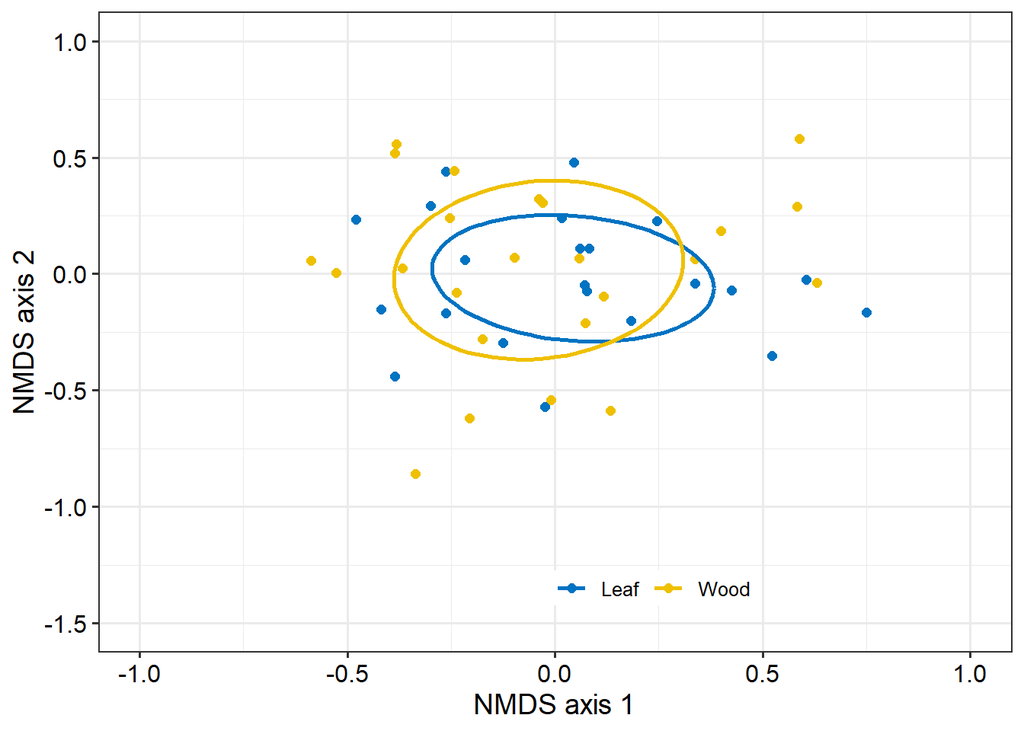

```r
# by organic matter type
nmds_OM <- ggplot(data = df,
                  aes(x = x, y = y))+
  geom_point(size = 2, aes(color = OM)) +
  geom_path(data = ell_OM_12,
            aes(x = x, y = y, color = OM),
            size = 1)+
  labs(x = "NMDS axis 1",
       y = "NMDS axis 2")+
  guides(color = guide_legend(ncol = 2))+
  theme(legend.position = c(0.6, 0.1),
        legend.background = element_blank(),
        legend.direction = 'horizontal')+
  scale_color_jco(name = element_blank())+
  lims(x = c(-1, 1), y = c(-1.5, 1))
nmds_OM
```

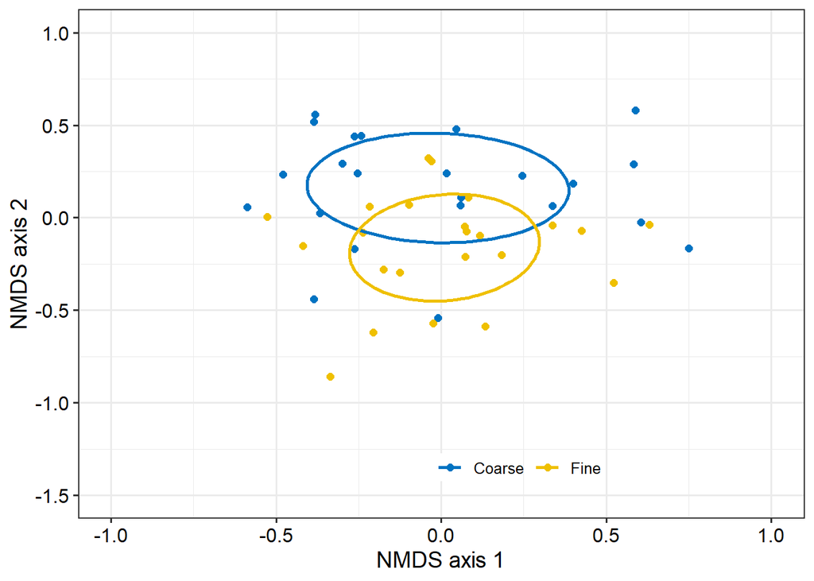

```r
# by mesh size
nmds_mesh <- ggplot(data = df,
                    aes(x = x, y = y))+
  geom_point(size = 2, aes(color = Mesh)) +
  geom_path(data = ell_mesh_12,
            aes(x = x, y = y, color = Mesh),
            size = 1)+
  labs(x = "NMDS axis 1",
       y = "NMDS axis 2")+
  guides(color = guide_legend(ncol = 2))+
  theme(legend.position = c(0.6, 0.1),
        legend.background = element_blank(),
        legend.direction = 'horizontal')+
  scale_color_jco(name = element_blank())+
  lims(x = c(-1, 1), y = c(-1.5, 1))
nmds_mesh
```

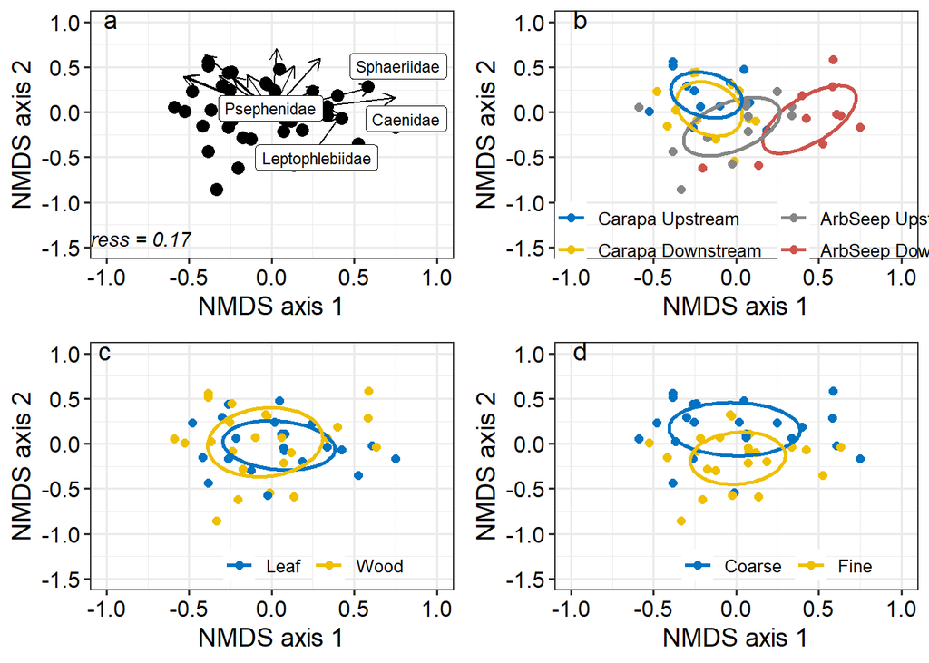

```r
# combine plots
Fig6 <- plot_grid(nmds_vect, nmds_reaches,
                  nmds_OM, nmds_mesh,
                  align = 'hv',
                  labels = 'auto', label_fontface = 'plain',
                  hjust = -7.5)
Fig6
```

# Table 4

Effect size values, measured as Hedges’ g.

```r
# Macroinvertebrate abundance
fam_long <-
  macro_fam %>%
  pivot_longer(cols = Chironomidae:Hydracarina,
               names_to = 'family', values_to = 'count') %>%
  dplyr::select(Sample:Reach, Reaches, family, count)

cohen.d(data = fam_long %>%
          dplyr::filter(Site == "Carapa"),
        count ~ Reach, na.rm = TRUE,
        hedges.correction = TRUE,
        conf.level = 0.95)
```

```
##
## Hedges's g
##
## g estimate: -0.04040886 (negligible)
## 95 percent confidence interval:
##       lower       upper
## -0.13893948  0.05812177
```

```r
cohen.d(data = fam_long %>%
          dplyr::filter(Site == "ArbSeep"),
        count ~ Reach, na.rm = TRUE,
        hedges.correction = TRUE,
        conf.level = 0.95)
```

```
##
## Hedges's g
##
## g estimate: 0.0169363 (negligible)
## 95 percent confidence interval:
##       lower       upper
## -0.08380157  0.11767417
```

```r
# Macroinvertebrate richness
cohen.d(data = macro_fam %>%
          dplyr::filter(Site == "Carapa"),
        numFam ~ Reach, na.rm = TRUE,
        hedges.correction = TRUE,
        conf.level = 0.95)
```

```
##
## Hedges's g
##
## g estimate: -0.2706112 (small)
## 95 percent confidence interval:
##      lower      upper
## -0.8447683  0.3035459
```

```r
cohen.d(data = macro_fam %>%
          dplyr::filter(Site == "ArbSeep"),
        numFam ~ Reach, na.rm = TRUE,
        hedges.correction = TRUE,
        conf.level = 0.95)
```

```
##
## Hedges's g
##
## g estimate: 0.3377396 (small)
## 95 percent confidence interval:
##      lower      upper
## -0.2510704  0.9265496
```

```r
# leaf litter decomposition rates
cohen.d(data = dplyr::filter(OM, Stream == "Carapa"),
        k_LL_d ~ Treatment, na.rm = TRUE,
        hedges.correction = TRUE,
        conf.level = 0.95)
```

```
##
## Hedges's g
##
## g estimate: 0.1413517 (negligible)
## 95 percent confidence interval:
##     lower     upper
## -1.047592  1.330295
```

```r
cohen.d(data = dplyr::filter(OM, Stream == "Arb Seep"),
        k_LL_d ~ Treatment, na.rm = TRUE,
        hedges.correction = TRUE,
        conf.level = 0.95)
```

```
##
## Hedges's g
##
## g estimate: -0.0783361 (negligible)
## 95 percent confidence interval:
##     lower     upper
## -1.423300  1.266628
```

```r
# CWD decomposition rates
cohen.d(data = dplyr::filter(OM, Stream == "Carapa"),
        k_CWD_yr ~ Treatment, na.rm = TRUE,
        hedges.correction = TRUE,
        conf.level = 0.95)
```

```
##
## Hedges's g
##
## g estimate: 0.0658644 (negligible)
## 95 percent confidence interval:
##     lower     upper
## -1.121919  1.253648
```

```r
cohen.d(data = dplyr::filter(OM, Stream == "Arb Seep"),
        k_CWD_yr ~ Treatment, na.rm = TRUE,
        hedges.correction = TRUE,
        conf.level = 0.95)
```

```
##
## Hedges's g
##
## g estimate: 0.2210009 (small)
## 95 percent confidence interval:
##      lower      upper
## -0.9700799  1.4120816
```

```r
# Chironomid %growth
cohen.d(data = chiroGrowth %>%
          dplyr::filter(Reach %in% c("Carapa Upstream", "Carapa Downstream")),
        delBiomass_per ~ Reach,
        na.rm = TRUE,
        hedges.correction = TRUE,
        conf.level = 0.95)
```

```
##
## Hedges's g
##
## g estimate: NaN (NA)
## 95 percent confidence interval:
## lower upper
##   NaN   NaN
```

```r
cohen.d(data = chiroGrowth %>%
          dplyr::filter(Reach %in% c("ArbSeep Upstream", "ArbSeep Downstream")),
        delBiomass_per ~ Reach,
        hedges.correction = TRUE,
        conf.level = 0.95)
```

```
##
## Hedges's g
##
## g estimate: 0.6729998 (medium)
## 95 percent confidence interval:
##      lower      upper
## -0.2943058  1.6403054
```

# Supplementary Tables and Figures

## Table S1

```r
LL_nest <- lm(k_LL_d ~ (Stream/Treatment)*Bag_mesh,
              data = OM)
summary(LL_nest)
```

```
##
## Call:
## lm(formula = k_LL_d ~ (Stream/Treatment) * Bag_mesh, data = OM)
##
## Residuals:
##        Min         1Q     Median         3Q        Max
## -0.0127500 -0.0017293  0.0003339  0.0017625  0.0108400
##
## Coefficients:
##                                               Estimate Std. Error t value
## (Intercept)                                  0.0459900  0.0046930   9.800
## StreamCarapa                                -0.0066733  0.0060587  -1.101
## Bag_meshFine                                -0.0017145  0.0066370  -0.258
## StreamArb Seep:TreatmentUnbuff              -0.0007693  0.0060587  -0.127
## StreamCarapa:TreatmentUnbuff                -0.0022700  0.0054191  -0.419
## StreamCarapa:Bag_meshFine                    0.0032078  0.0085683   0.374
## StreamArb Seep:TreatmentUnbuff:Bag_meshFine  0.0017635  0.0085683   0.206
## StreamCarapa:TreatmentUnbuff:Bag_meshFine    0.0021110  0.0076637   0.275
##                                             Pr(>|t|)
## (Intercept)                                  1.2e-07 ***
## StreamCarapa                                   0.289
## Bag_meshFine                                   0.800
## StreamArb Seep:TreatmentUnbuff                 0.901
## StreamCarapa:TreatmentUnbuff                   0.682
## StreamCarapa:Bag_meshFine                      0.714
## StreamArb Seep:TreatmentUnbuff:Bag_meshFine    0.840
## StreamCarapa:TreatmentUnbuff:Bag_meshFine      0.787
## ---
## Signif. codes:  0 '***' 0.001 '**' 0.01 '*' 0.05 '.' 0.1 ' ' 1
##
## Residual standard error: 0.006637 on 14 degrees of freedom
##   (2 observations deleted due to missingness)
## Multiple R-squared:  0.2542, Adjusted R-squared:  -0.1187
## F-statistic: 0.6817 on 7 and 14 DF,  p-value: 0.6858
```

```r
anova(LL_nest)
```

```
## Analysis of Variance Table
##
## Response: k_LL_d
##                           Df     Sum Sq    Mean Sq F value Pr(>F)
## Stream                     1 0.00017997 1.7997e-04  4.0857 0.0628 .
## Bag_mesh                   1 0.00000656 6.5570e-06  0.1489 0.7054
## Stream:Treatment           2 0.00000446 2.2280e-06  0.0506 0.9509
## Stream:Bag_mesh            1 0.00001401 1.4009e-05  0.3180 0.5817
## Stream:Treatment:Bag_mesh  2 0.00000521 2.6040e-06  0.0591 0.9428
## Residuals                 14 0.00061669 4.4049e-05
## ---
## Signif. codes:  0 '***' 0.001 '**' 0.01 '*' 0.05 '.' 0.1 ' ' 1
```

```r
Anova(LL_nest, type = 'III')
```

```
## Anova Table (Type III tests)
##
## Response: k_LL_d
##                              Sum Sq Df F value  Pr(>F)
## (Intercept)               0.0042302  1 96.0322 1.2e-07 ***
## Stream                    0.0000534  1  1.2132  0.2893
## Bag_mesh                  0.0000029  1  0.0667  0.7999
## Stream:Treatment          0.0000084  2  0.0958  0.9092
## Stream:Bag_mesh           0.0000062  1  0.1402  0.7137
## Stream:Treatment:Bag_mesh 0.0000052  2  0.0591  0.9428
## Residuals                 0.0006167 14
## ---
## Signif. codes:  0 '***' 0.001 '**' 0.01 '*' 0.05 '.' 0.1 ' ' 1
```

```r
print(HSD.test(LL_nest, trt = 'Bag_mesh'))
```

```
## $statistics
##       MSerror Df       Mean       CV         MSD
##   4.40494e-05 14 0.04206705 15.77713 0.006069777
##
## $parameters
##    test   name.t ntr StudentizedRange alpha
##   Tukey Bag_mesh   2         3.033186  0.05
##
## $means
##            k_LL_d         std  r     Min     Max      Q25      Q50       Q75
## Coarse 0.04152109 0.005207339 11 0.03438 0.04745 0.036780 0.044670 0.0454825
## Fine   0.04261300 0.007410619 11 0.02806 0.05165 0.043062 0.044001 0.0462025
##
## $comparison
## NULL
##
## $groups
##            k_LL_d groups
## Fine   0.04261300      a
## Coarse 0.04152109      a
##
## attr(,"class")
## [1] "group"
```

```r
print(HSD.test(LL_nest, trt = 'Stream'))
```

```
## $statistics
##       MSerror Df       Mean       CV
##   4.40494e-05 14 0.04206705 15.77713
##
## $parameters
##    test name.t ntr StudentizedRange alpha
##   Tukey Stream   2         3.033186  0.05
##
## $means
##              k_LL_d         std  r      Min     Max       Q25      Q50
## Arb Seep 0.04520020 0.001223428 10 0.043404 0.04731 0.0445800 0.044711
## Carapa   0.03945608 0.007588574 12 0.028060 0.05165 0.0345975 0.038235
##                 Q75
## Arb Seep 0.04618000
## Carapa   0.04473725
##
## $comparison
## NULL
##
## $groups
##              k_LL_d groups
## Arb Seep 0.04520020      a
## Carapa   0.03945608      a
##
## attr(,"class")
## [1] "group"
```

```r
print(HSD.test(LL_nest, trt = 'Treatment'))
```

```
## $statistics
##       MSerror Df       Mean       CV
##   4.40494e-05 14 0.04206705 15.77713
##
## $parameters
##    test    name.t ntr StudentizedRange alpha
##   Tukey Treatment   2         3.033186  0.05
##
## $means
##           k_LL_d         std  r     Min     Max       Q25       Q50     Q75
## Buff   0.0420911 0.007118476 10 0.02806 0.05165 0.0377700 0.0442755 0.04665
## Unbuff 0.0420470 0.005806181 12 0.02914 0.04898 0.0386325 0.0442650 0.04606
##
## $comparison
## NULL
##
## $groups
##           k_LL_d groups
## Buff   0.0420911      a
## Unbuff 0.0420470      a
##
## attr(,"class")
## [1] "group"
```

```r
CWD_nest <- lm(k_CWD_yr ~ (Stream/Treatment)*Bag_mesh,
               data = OM)
summary(CWD_nest)
```

```
##
## Call:
## lm(formula = k_CWD_yr ~ (Stream/Treatment) * Bag_mesh, data = OM)
##
## Residuals:
##      Min       1Q   Median       3Q      Max
## -1.40695 -0.23055 -0.03555  0.19094  1.07225
##
## Coefficients:
##                                             Estimate Std. Error t value
## (Intercept)                                  2.02503    0.34737   5.830
## StreamCarapa                                -1.13142    0.49125  -2.303
## Bag_meshFine                                 0.83245    0.49125   1.695
## StreamArb Seep:TreatmentUnbuff              -0.07732    0.49125  -0.157
## StreamCarapa:TreatmentUnbuff                 0.05369    0.49125   0.109
## StreamCarapa:Bag_meshFine                   -1.07301    0.69474  -1.544
## StreamArb Seep:TreatmentUnbuff:Bag_meshFine -0.18688    0.69474  -0.269
## StreamCarapa:TreatmentUnbuff:Bag_meshFine   -0.18186    0.69474  -0.262
##                                             Pr(>|t|)
## (Intercept)                                 2.56e-05 ***
## StreamCarapa                                   0.035 *
## Bag_meshFine                                   0.110
## StreamArb Seep:TreatmentUnbuff                 0.877
## StreamCarapa:TreatmentUnbuff                   0.914
## StreamCarapa:Bag_meshFine                      0.142
## StreamArb Seep:TreatmentUnbuff:Bag_meshFine    0.791
## StreamCarapa:TreatmentUnbuff:Bag_meshFine      0.797
## ---
## Signif. codes:  0 '***' 0.001 '**' 0.01 '*' 0.05 '.' 0.1 ' ' 1
##
## Residual standard error: 0.6017 on 16 degrees of freedom
## Multiple R-squared:  0.7513, Adjusted R-squared:  0.6424
## F-statistic: 6.903 on 7 and 16 DF,  p-value: 0.0006981
```

```r
Anova(CWD_nest, type = 'III')
```

```
## Anova Table (Type III tests)
##
## Response: k_CWD_yr
##                            Sum Sq Df F value    Pr(>F)
## (Intercept)               12.3022  1 33.9845 2.561e-05 ***
## Stream                     1.9202  1  5.3044   0.03503 *
## Bag_mesh                   1.0395  1  2.8714   0.10954
## Stream:Treatment           0.0133  2  0.0184   0.98183
## Stream:Bag_mesh            0.8635  1  2.3854   0.14202
## Stream:Treatment:Bag_mesh  0.0510  2  0.0704   0.93227
## Residuals                  5.7919 16
## ---
## Signif. codes:  0 '***' 0.001 '**' 0.01 '*' 0.05 '.' 0.1 ' ' 1
```

## Table S2

```r
biomass_nested <- lm(data = chiroGrowth,
                     log10(delBiomass_per) ~ Stream/Trt_Reach)
summary(biomass_nested)
```

```
##
## Call:
## lm(formula = log10(delBiomass_per) ~ Stream/Trt_Reach, data = chiroGrowth)
##
## Residuals:
##      Min       1Q   Median       3Q      Max
## -0.81215 -0.16892 -0.08248  0.30771  0.77650
##
## Coefficients:
##                                   Estimate Std. Error t value Pr(>|t|)
## (Intercept)                        2.18229    0.13196  16.538 1.27e-14 ***
## StreamCarapa                      -0.51024    0.20564  -2.481   0.0205 *
## StreamArbSeep:Trt_ReachUnbuffered -0.47606    0.24687  -1.928   0.0657 .
## StreamCarapa:Trt_ReachUnbuffered   0.09569    0.22305   0.429   0.6718
## ---
## Signif. codes:  0 '***' 0.001 '**' 0.01 '*' 0.05 '.' 0.1 ' ' 1
##
## Residual standard error: 0.4173 on 24 degrees of freedom
##   (11 observations deleted due to missingness)
## Multiple R-squared:  0.2543, Adjusted R-squared:  0.1611
## F-statistic: 2.728 on 3 and 24 DF,  p-value: 0.06628
```

```r
Anova(biomass_nested, type = 'III')
```

```
## Anova Table (Type III tests)
##
## Response: log10(delBiomass_per)
##                  Sum Sq Df  F value    Pr(>F)
## (Intercept)      47.624  1 273.4995 1.273e-14 ***
## Stream            1.072  1   6.1564   0.02049 *
## Stream:Trt_Reach  0.680  2   1.9513   0.16398
## Residuals         4.179 24
## ---
## Signif. codes:  0 '***' 0.001 '**' 0.01 '*' 0.05 '.' 0.1 ' ' 1
```

```r
biomass_chg_nested <- lm(data = chiroGrowth,
                         log10(biomassFin_mg) ~ (Stream/Trt_Reach))
summary(biomass_chg_nested)
```

```
##
## Call:
## lm(formula = log10(biomassFin_mg) ~ (Stream/Trt_Reach), data = chiroGrowth)
##
## Residuals:
##      Min       1Q   Median       3Q      Max
## -0.72862 -0.13517 -0.01097  0.12452  0.53851
##
## Coefficients:
##                                   Estimate Std. Error t value Pr(>|t|)
## (Intercept)                       -1.17591    0.07886 -14.911  3.2e-16 ***
## StreamCarapa                      -0.39114    0.12777  -3.061  0.00436 **
## StreamArbSeep:Trt_ReachUnbuffered -0.41112    0.13330  -3.084  0.00411 **
## StreamCarapa:Trt_ReachUnbuffered   0.04745    0.13816   0.343  0.73348
## ---
## Signif. codes:  0 '***' 0.001 '**' 0.01 '*' 0.05 '.' 0.1 ' ' 1
##
## Residual standard error: 0.2843 on 33 degrees of freedom
##   (2 observations deleted due to missingness)
## Multiple R-squared:  0.3159, Adjusted R-squared:  0.2537
## F-statistic:  5.08 on 3 and 33 DF,  p-value: 0.005308
```

```r
Anova(biomass_chg_nested, type = 'III')
```

```
## Anova Table (Type III tests)
##
## Response: log10(biomassFin_mg)
##                   Sum Sq Df  F value    Pr(>F)
## (Intercept)      17.9758  1 222.3420 3.203e-16 ***
## Stream            0.7577  1   9.3718  0.004359 **
## Stream:Trt_Reach  0.7786  2   4.8151  0.014626 *
## Residuals         2.6680 33
## ---
## Signif. codes:  0 '***' 0.001 '**' 0.01 '*' 0.05 '.' 0.1 ' ' 1
```

## Fig S1

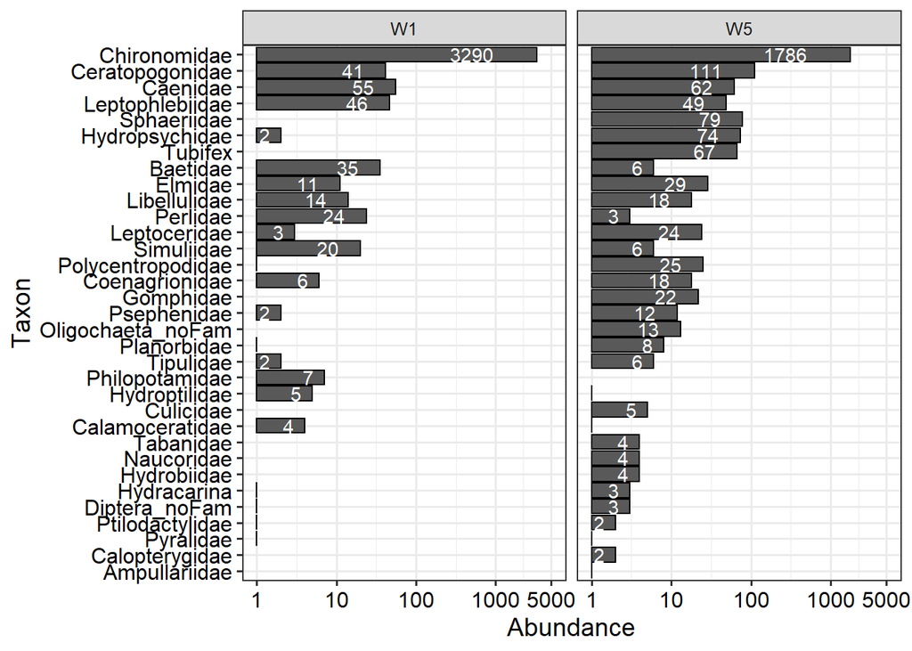

```r
family_long <-
  macro_fam %>%
  #mutate(Hydracarina = Hydracarina + Water.Mite) %>%
  #select(-Water.Mite) %>%
  pivot_longer(cols = Chironomidae:Hydracarina,
               names_to = 'family', values_to = 'count') %>%
  dplyr::select(Sample:Mesh, Reaches, family, count)


Fig_S1 <- ggplot(data = family_long %>%
                   dplyr::group_by(family, Week) %>%
                   dplyr::summarise(sum = sum(count)),
                 aes(x = reorder(family, sum), y = sum))+
  geom_bar(stat = 'identity', color = 'black')+
  geom_text(aes(label = sum), hjust = 2, color = 'white')+
  coord_flip()+
  facet_grid(.~Week)+
  scale_y_log10(limits = c(1, 5000),
                breaks = c(1, 10, 100, 1000, 5000),
                labels = c(1, 10, 100, 1000, 5000))+
  xlab('Taxon')+
  ylab("Abundance")
Fig_S1
```

## Fig S2

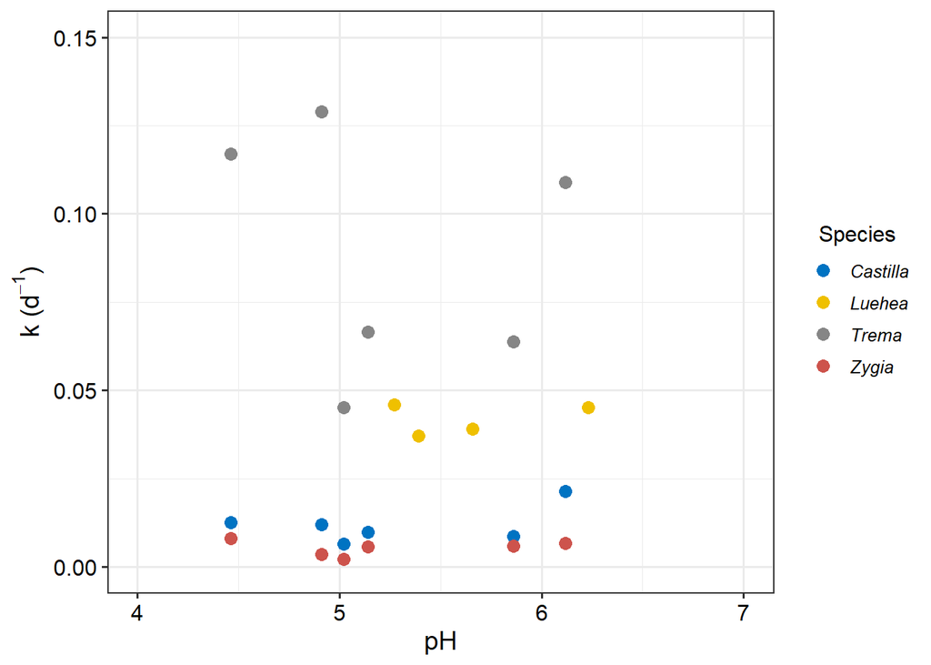

```r
k_pH = read_excel("Data/decomp and pH.xlsx",
                  sheet = "Sheet2")
ggplot(k_pH, aes(x = pH, y = k))+
  geom_point(aes(color = Species),
             size = 3)+
  scale_color_jco()+
  ylim(0, 0.15)+
  xlim(4, 7)+
  ylab(expression(paste("k (", d^-1,")")))+
  theme(legend.text = element_text(face = 'italic'))
```

**R version 4.0.3 (2020-10-10)**

**Platform:** x86_64-w64-mingw32/x64 (64-bit)

**locale:** *LC_COLLATE=English_United States.1252*, *LC_CTYPE=English_United States.1252*, *LC_MONETARY=English_United States.1252*, *LC_NUMERIC=C* and *LC_TIME=English_United States.1252*

**attached base packages:** *stats*, *graphics*, *grDevices*, *utils*, *datasets*, *methods* and *base*

**other attached packages:** *pander(v.0.6.4)*, *scales(v.1.1.1)*, *ggrepel(v.0.9.1)*, *vegan(v.2.5-7)*, *lattice(v.0.20-45)*, *permute(v.0.9-5)*, *ARTool(v.0.11.1)*, *effsize(v.0.8.1)*, *car(v.3.0-12)*, *carData(v.3.0-4)*, *emmeans(v.1.7.1-1)*, *moments(v.0.14)*, *ggsci(v.2.9)*, *agricolae(v.1.3-5)*, *cowplot(v.1.1.1)*, *lubridate(v.1.8.0)*, *ggplot2(v.3.3.5)*, *tidyr(v.1.1.4)*, *dplyr(v.1.0.7)* and *readxl(v.1.3.1)*

**loaded via a namespace (and not attached):** *nlme(v.3.1-153)*, *tools(v.4.0.3)*, *bslib(v.0.3.1)*, *utf8(v.1.2.2)*, *R6(v.2.5.1)*, *AlgDesign(v.1.2.0)*, *mgcv(v.1.8-38)*, *DBI(v.1.1.1)*, *questionr(v.0.7.5)*, *colorspace(v.2.0-2)*, *withr(v.2.4.3)*, *tidyselect(v.1.1.1)*, *klaR(v.0.6-15)*, *compiler(v.4.0.3)*, *cli(v.3.1.0)*, *sandwich(v.3.0-1)*, *labeling(v.0.4.2)*, *sass(v.0.4.0)*, *mvtnorm(v.1.1-3)*, *stringr(v.1.4.0)*, *digest(v.0.6.29)*, *minqa(v.1.2.4)*, *rmarkdown(v.2.11)*, *pkgconfig(v.2.0.3)*, *htmltools(v.0.5.2)*, *lme4(v.1.1-27.1)*, *labelled(v.2.9.0)*, *fastmap(v.1.1.0)*, *highr(v.0.9)*, *rlang(v.0.4.12)*, *rstudioapi(v.0.13)*, *shiny(v.1.7.1)*, *farver(v.2.1.0)*, *jquerylib(v.0.1.4)*, *generics(v.0.1.1)*, *zoo(v.1.8-9)*, *combinat(v.0.0-8)*, *jsonlite(v.1.7.2)*, *magrittr(v.2.0.1)*, *Matrix(v.1.4-0)*, *Rcpp(v.1.0.7)*, *munsell(v.0.5.0)*, *fansi(v.0.5.0)*, *abind(v.1.4-5)*, *lifecycle(v.1.0.1)*, *stringi(v.1.7.6)*, *multcomp(v.1.4-17)*, *yaml(v.2.2.1)*, *MASS(v.7.3-54)*, *plyr(v.1.8.6)*, *grid(v.4.0.3)*, *parallel(v.4.0.3)*, *promises(v.1.2.0.1)*, *forcats(v.0.5.1)*, *crayon(v.1.4.2)*, *miniUI(v.0.1.1.1)*, *haven(v.2.4.3)*, *splines(v.4.0.3)*, *hms(v.1.1.1)*, *knitr(v.1.37)*, *pillar(v.1.6.4)*, *boot(v.1.3-28)*, *estimability(v.1.3)*, *codetools(v.0.2-18)*, *glue(v.1.6.0)*, *evaluate(v.0.14)*, *vctrs(v.0.3.8)*, *nloptr(v.1.2.2.3)*, *httpuv(v.1.6.4)*, *cellranger(v.1.1.0)*, *gtable(v.0.3.0)*, *purrr(v.0.3.4)*, *assertthat(v.0.2.1)*, *xfun(v.0.29)*, *mime(v.0.12)*, *xtable(v.1.8-4)*, *later(v.1.3.0)*, *survival(v.3.2-13)*, *tibble(v.3.1.6)*, *cluster(v.2.1.2)*, *TH.data(v.1.1-0)* and *ellipsis(v.0.3.2)*